# Restaurants Delivery Times

Om Ajay Karthik

3/10/2021

Restaurants Delivery Times

In this section, you will analyze the restaurant’s delivery times. To perform the following analysis, you will need to join the Restaurants information and Restaurants delivery time datasets using their restaurant_id and rest_key primary keys. Answer the following questions:

Count the number of neighborhoods where each restaurant delivers. (Each restaurant can deliver to multiple neighborhoods, independently from here the restaurants is physically located) Present in a bar chart the top 15 neighborhoods by the number of restaurants where restaurants make deliveries. (You will need to count the number of restaurants that deliver to each neighborhood) Compute the average delivery time for each restaurant. (Compute the average of all neighborhoods the restaurant delivers) Present in tabular format the top 20 restaurants by fasted average delivery time. In the same table, present the rating score, and postcode.

Installing necessary packages

```r
 #install.packages('ggplot2')
 #install.packages('dplyr')
 #install.packages("tidyverse")

 #install.packages("xlsx")
 #install.packages('expss')
 #install.packages('gridExtra')
 #install.packages('purrrlyr')
 #install.packages('ggpubr')
 #install.packages('data.table')
```

Importing necessary libraries

```r
library(ggpubr)
```

```r
library(ggplot2)
library(dplyr)
library(gridExtra)
library(tidyverse)
library(purrrlyr)
library(data.table)
```

Imporing datasets

```r
resturants_mibe <- readRDS("C:/Users/Om Ajay Karthik/Desktop/LSU/resturants-mibe.rds")
delivery_mibe <- readRDS("C:/Users/Om Ajay Karthik/Desktop/LSU/delivery-mibe.rds")
```

Right outer join table and create a duplicate dataframe

```r
resturant_delivery = merge(x = resturants_mibe, y = delivery_mibe, by.x='restaurant_id', by.y='rest_key', all.y = TRUE)

rest_delivery_merged_subset = resturant_delivery %>% select(restaurant_id,rest_name,rest_neighborhood,rest_postcode,neighborhood_name,rest_rating,rest_delivery_time_min)
```

### 1. Count the number of neighborhoods where each restaurant delivers. (Each restaurant can deliver to multiple neighborhoods, independently from here the restaurants is physically located)

```r
neighbourhoods_delivery_count = rest_delivery_merged_subset %>%
  select(rest_name,neighborhood_name)   %>%
  group_by(rest_name,neighborhood_name) %>%
  unique() %>%
  summarise(n = n()) %>% count()
names(neighbourhoods_delivery_count)[1] <- "Restaurant Name"
names(neighbourhoods_delivery_count)[2] <- "No of Neighbourhood Delivery by Resturant"
```

```r
writeLines("td, th { padding : 6px } th { background-color : brown ; color : white; border : 1px solid white; } td { color : brown ; border : 1px solid brown }", con = "mystyle.css")
dset1 <- head(neighbourhoods_delivery_count,n=10)
knitr::kable(dset1, format = "html")
```

| Restaurant Name | No of Neighbourhood Delivery by Resturant |
| --- | --- |
| &Cake – Wembley | 6 |
| 🇯🇵🇧🇷 YOOBI 🍣 | 16 |
| 🌶 BOMBAY BICYCLE CHEF 🌶 | 16 |
| 🏄 Honi Poke - Mayfair🏄 | 31 |
| 🏄 Honi Poke - Soho🏄 | 10 |
| 👑 Benito’s Hat 👑 | 18 |
| 大华小吃 Da Hua Street Food | 5 |
| 大华快餐(Dahua Fast Food) | 5 |
| 婆婆 Popo Chinese, Oriental, Thai & Dim Sum Cuisine | 5 |
| 東園小館 - East Garden | 2 |

### 2. Present in a bar chart the top 15 neighborhoods by the number of restaurants where restaurants make deliveries.(You will need to count the number of restaurants that deliver to each neighborhood)

```r
restaurants_per_neighbourhood = rest_delivery_merged_subset %>%
  select(rest_name,neighborhood_name)   %>%
  group_by(neighborhood_name,rest_name) %>%
  unique() %>%
  summarise(n = n()) %>%
  count()%>%
  arrange(-n)
```

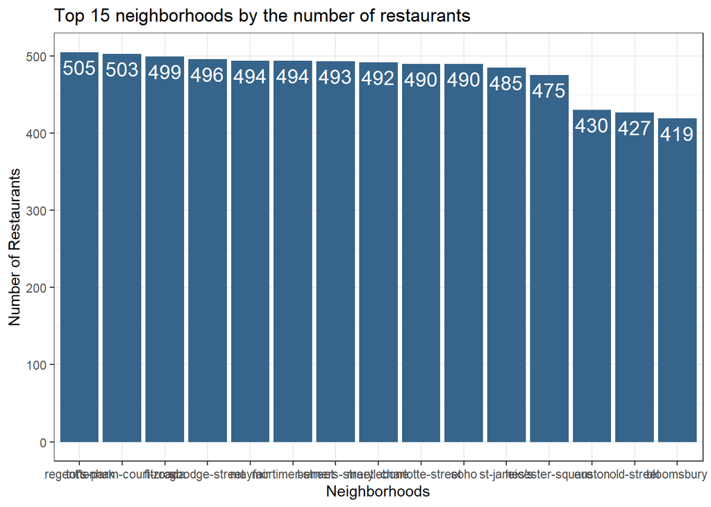

```r
names(restaurants_per_neighbourhood)[2] <- "No_of_Restaurants"

top_n_restaurants_per_neighbourhood = head(restaurants_per_neighbourhood,n=15)
ggplot(top_n_restaurants_per_neighbourhood, aes(x = reorder(neighborhood_name, -No_of_Restaurants), y = No_of_Restaurants)) +
  geom_bar(stat="identity", fill="steelblue4")+
  geom_text(aes(label=No_of_Restaurants), vjust=1.5, color="white", size=5)+
  labs(title = "Top 15 neighborhoods by the number of restaurants") +
  xlab("Neighborhoods") +
  ylab("Number of Restaurants") +
  theme_bw()
```

### 3. Compute the average delivery time for each restaurant. (Compute the average of all neighborhoods the restaurant delivers)

```r
resturant_avg_delivery_time = rest_delivery_merged_subset %>%
  select(rest_name,neighborhood_name,rest_delivery_time_min)   %>%
  filter(!is.na(rest_delivery_time_min)) %>%
  group_by(rest_name) %>%
  summarise(average_delivery_time = mean(rest_delivery_time_min))
```

```r
writeLines("td, th { padding : 6px } th { background-color : brown ; color : white; border : 1px solid white; } td { color : brown ; border : 1px solid brown }", con = "mystyle.css")
dset1 <- head(resturant_avg_delivery_time,n=50)
knitr::kable(dset1, format = "html")
```

| rest_name | average_delivery_time |
| --- | --- |
| &Cake – Wembley | 22.77778 |
| 🇯🇵🇧🇷 YOOBI 🍣 | 20.62500 |
| 🌶 BOMBAY BICYCLE CHEF 🌶 | 36.91176 |
| 🏄 Honi Poke - Mayfair🏄 | 21.07143 |
| 🏄 Honi Poke - Soho🏄 | 11.62500 |
| 👑 Benito’s Hat 👑 | 24.22535 |
| 大华小吃 Da Hua Street Food | 25.00000 |
| 大华快餐(Dahua Fast Food) | 25.00000 |
| 婆婆 Popo Chinese, Oriental, Thai & Dim Sum Cuisine | 22.66667 |
| 東園小館 - East Garden | 21.66667 |
| 米Kome Japanese & Korean Sushi | 18.51562 |
| 食全小厨 FODAL Oriental Kitchen | 17.50000 |
| 11 Coffee and Co | 27.14286 |
| 14228 - Burger King | 21.87500 |
| 2 Girls’ Cafe | 21.58537 |
| 201 Asian Kitchen | 27.50000 |
| 24/7 Supermarket | 16.00000 |
| 36 Streets Food | 27.36111 |
| 4021 Firezza | 15.00000 |
| 491094Adam’s Cafe | 28.23529 |
| 5 Star Pizza | 23.25000 |
| 500 Degrees Pizzeria | 17.33333 |
| 696 mangal | 16.83333 |
| 805 Restaurant | 30.00000 |
| A’La Pizza | 26.17647 |
| A Burgers by Taster | 23.43750 |
| A K Chicken | 21.11111 |
| A&Y Wines Beers | 13.98438 |
| A.D Food & Wine | 16.18750 |
| A1 Kebabish | 21.66667 |
| Aachis Masala Chennai | 25.00000 |
| Abbotshill Wine Bar & Deli | 16.66667 |
| Abby’s Food and Wine | 23.57143 |
| Abshar | 29.16667 |
| Abu Zaad | 25.00000 |
| Abu Zaad - Ealing | 20.00000 |
| Acacus | 39.00000 |
| Acai Berry | 12.30159 |
| Açaí Sisters | 31.56716 |
| Adam’s Ethiopian Restaurant | 51.94444 |
| Adana | 22.26190 |
| Ading’s Kitchen | 31.56250 |
| AFC Fried Chicken & Pizza | 31.30952 |
| Afters | 20.95238 |
| Afters Original | 21.66667 |
| Aglio e Olio | 31.25000 |
| Agora Greek Bakery | 16.62500 |
| Aha Wok | 23.12500 |
| Ahaa Dosa | 25.29412 |
| Ahi Poké | 12.68657 |

```r
resturant_avg_delivery_time_rating_postcode = rest_delivery_merged_subset %>%
select(rest_name,neighborhood_name,rest_rating,rest_delivery_time_min,rest_postcode)   %>%
group_by(rest_name) %>%
unique() %>%
summarise(rest_name,neighborhood_name,rest_rating,rest_delivery_time_min,rest_postcode,average_delivery_time = mean(rest_delivery_time_min))
resturant_avg_delivery_time_rating_postcode_desc <-resturant_avg_delivery_time_rating_postcode[order(resturant_avg_delivery_time_rating_postcode$average_delivery_time),]
resturant_avg_delivery_time_rating_postcode_desc_top_n = resturant_avg_delivery_time_rating_postcode_desc %>% select(rest_name,rest_postcode,neighborhood_name,rest_rating,average_delivery_time) %>% head(., n=20)
```

```r
writeLines("td, th { padding : 6px } th { background-color : brown ; color : white; border : 1px solid white; } td { color : brown ; border : 1px solid brown }", con = "mystyle.css")
dset1 <- head(resturant_avg_delivery_time_rating_postcode_desc_top_n,n=50)
knitr::kable(dset1, format = "html")
```

| rest_name | rest_postcode | neighborhood_name | rest_rating | average_delivery_time |
| --- | --- | --- | --- | --- |
| Vagabond Wines - Fulham | SW61AX | fulham | 4.8 | 8.000000 |
| Vagabond Wines - Fulham | SW61AX | parsons-green | 4.8 | 8.000000 |
| Vagabond Wines - Fulham | SW61AX | earl’s-court | 4.8 | 8.000000 |
| Vagabond Wines - Fulham | SW61AX | west-kensington | 4.8 | 8.000000 |
| Vagabond Wines - Fulham | SW61AX | south-kensington | 4.8 | 8.000000 |
| OREE | SW109PZ | knightsbridge | 4.8 | 8.333333 |
| OREE | SW109PZ | south-kensington | 4.8 | 8.333333 |
| OREE | SW109PZ | chelsea | 4.8 | 8.333333 |
| OREE | SW109PZ | parsons-green | 4.8 | 8.333333 |
| OREE | SW109PZ | belgravia | 4.8 | 8.333333 |
| OREE | SW109PZ | fulham | 4.8 | 8.333333 |
| Amorino - Old Compton St | W1D6HF | st-james’s | 4.8 | 10.000000 |
| Amorino - Old Compton St | W1D6HF | leicester-square | 4.8 | 10.000000 |
| Amorino - Old Compton St | W1D6HF | soho | 4.8 | 10.000000 |
| Amorino - Old Compton St | W1D6HF | westminster | 4.8 | 10.000000 |
| Amorino - Old Compton St | W1D6HF | mayfair | 4.8 | 10.000000 |
| Andys Quality Fish & Chips | W139RJ | ealing | 4.6 | 10.000000 |
| Bill’s Breakfast | W52XA | ealing | 4.6 | 10.000000 |
| Brew Café | SW195DX | wimbledon | 4.5 | 10.000000 |
| Chic-o-land Kebab | KT12AA | molesey | NA | 10.000000 |